# Project 2 - Group 2 Homework Part 2

Vinicio Haro

Sang Yoon (Andy) Hwang

Julian McEachern

Jeremy O’Brien

Bethany Poulin

10 December 2019

# Getting Started

## Dependencies

```r
# Predicitve Modeling
libraries("AppliedPredictiveModeling", "mice", "caret", "tidyverse",
    "impute", "pls", "caTools", "mlbench", "car", "olsrr", "neuralnet",
    "nnet")
# Formatting Libraries
libraries("default", "knitr", "kableExtra", "readxl", "sqldf",
    "sjPlot", "sjmisc", "sjlabelled", "MASS")
# Plotting Libraries
libraries("ggplot2", "grid", "ggfortify", "DataExplorer", "ggcorrplot")
```

# Project 2

\begin{question}{Project #2 - Requirement}You are given a simple data set from a beverage manufacturing company. It consists of 2,571 rows/cases of data and 33 columns / variables. Your goal is to use this data to predict PH (a column in the set). PH is a measure of acidity/alkalinity, it must conform in a critical range and therefore it is important to understand its influence and predict its values. This is production data. PH is a KPI, Key Performance Indicator.

You are also given a scoring set (267 cases). All variables other than the dependent or target. You will use this data to score your model with your best predictions. :\end{question}

# Introduction

The goal of this project is to predict `PH`, a measure of acidity/alkalinity, using train data set from a beverage company which consists of 2571 rows of data and 33 variables. After creating models based on training data, we will test on scoring set of 267 rows with 32 variables (excluding target variable which is `PH` in our training set)

As a group project, each member of the group is responsible for creating their own models of choice. For instance, my own selections were `Linear model` and `NNet`. However, the choice of models can be altered after careful review of data exploration - it may require different type of model in case data suffers from outliers or any other data related issues.

Explaining why some necessary steps were applied before modeling and model A was preferred to Model B is often a topic in academic papers which is a meaningful topic that helps audience learn the concept of bagged regression and least square method better.

# Data Exploration

## Data dictionary

The table below describes the variables in the train data set.

Data dictionary

| Name | Type | MD code | Length | Measurement Type | Excluded |
| --- | --- | --- | --- | --- | --- |
| Test Time | Double | -9999 | 8 | m/d/yy h:mm Am/Pm | Auto |
| Brand Code | Double | -9999 | 8 | General | Categorical |
| Carb Volume | Double | -9999 | 8 | General | Auto |
| Fill Ounces | Double | -9999 | 8 | General | Auto |
| PC Volume | Double | -9999 | 8 | General | Auto |
| Carb Pressure | Double | -9999 | 8 | General | Auto |
| Carb Temp | Double | -9999 | 8 | General | Auto |
| PSC | Double | -9999 | 8 | General | Auto |
| PSC Fill | Double | -9999 | 8 | General | Auto |
| PSC CO2 | Double | -9999 | 8 | General | Auto |
| Mnf Flow | Double | -9999 | 8 | General | Auto |
| Carb Pressure1 | Double | -9999 | 8 | General | Auto |
| Fill Pressure | Double | -9999 | 8 | General | Auto |
| Hyd Pressure1 | Double | -9999 | 8 | General | Auto |
| Hyd Pressure2 | Double | -9999 | 8 | General | Auto |
| Hyd Pressure3 | Double | -9999 | 8 | General | Auto |
| Hyd Pressure4 | Double | -9999 | 8 | General | Auto |
| Filler Level | Double | -9999 | 8 | General | Auto |
| Filler Speed | Double | -9999 | 8 | General | Auto |
| Temperature | Double | -9999 | 8 | General | Auto |
| Usage cont | Double | -9999 | 8 | General | Auto |
| Carb Flow | Double | -9999 | 8 | General | Auto |
| Density | Double | -9999 | 8 | General | Auto |
| MFR | Double | -9999 | 8 | General | Auto |
| Balling | Double | -9999 | 8 | General | Auto |
| Pressure Vacuum | Double | -9999 | 8 | General | Auto |
| PH | Double | -9999 | 8 | General | Auto |
| Oxygen Filler | Double | -9999 | 8 | General | Auto |
| Bowl Setpoint | Double | -9999 | 8 | General | Auto |
| Pressure Setpoint | Double | -9999 | 8 | General | Auto |
| Air Pressurer | Double | -9999 | 8 | General | Auto |
| Alch Rel | Double | -9999 | 8 | General | Auto |
| Carb Rel | Double | -9999 | 8 | General | Auto |
| Balling Lvl | Double | -9999 | 8 | General | Auto |
| sample | Double | -999999998 | 8 | General | Auto |

Before we begin to try models against our data, we need to get an understanding of what our data looks like. We want to know what variables contain missing data. We also want to see the distributions of our target variable in addition to predictors. We need to establish a direction when it comes to pre-processing methods such as imputation, variable removal, and transformations. As a first step, we want to see the percentage of missing data per variable.

Distribution of Missing data in Beverage Manufacturing Company Data

|  | x |
| --- | --- |
| BrandCode | 4.67 |
| CarbVolume | 0.39 |
| FillOunces | 1.48 |
| PCVolume | 1.52 |
| CarbPressure | 1.05 |
| CarbTemp | 1.01 |
| PSC | 1.28 |
| PSCFill | 0.89 |
| PSCCO2 | 1.52 |
| MnfFlow | 0.08 |
| CarbPressure1 | 1.24 |
| FillPressure | 0.86 |
| HydPressure1 | 0.43 |
| HydPressure2 | 0.58 |
| HydPressure3 | 0.58 |
| HydPressure4 | 1.17 |
| FillerLevel | 0.78 |
| FillerSpeed | 2.22 |
| Temperature | 0.54 |
| Usagecont | 0.19 |
| CarbFlow | 0.08 |
| Density | 0.04 |
| MFR | 8.25 |
| Balling | 0.04 |
| PressureVacuum | 0.00 |
| PH | 0.16 |
| OxygenFiller | 0.47 |
| BowlSetpoint | 0.08 |
| PressureSetpoint | 0.47 |
| AirPressurer | 0.00 |
| AlchRel | 0.35 |
| CarbRel | 0.39 |
| BallingLvl | 0.04 |

MFR is missing 8.25% of its data followed by BrandCode,which is missing a little under 5% of its data. Brandcode isa categorical variable. The rest of our predictors are missing less than 3% of their data if not missing any at all. We can deal with these variables using a method of imputation. From our previous experience, we have used MICE succesfully as an imputation method. We have previously found that there does not seem to be major changes in the summary statistics across different imputation methods such as KNN or mean/mode. We also see that we are missing a small amount of data in the target variable (PH). PH is our ground truth, therefore it is better to remove rows where ground truth is missing without major data loss. We next examine the distribution of our response and predictor variables.

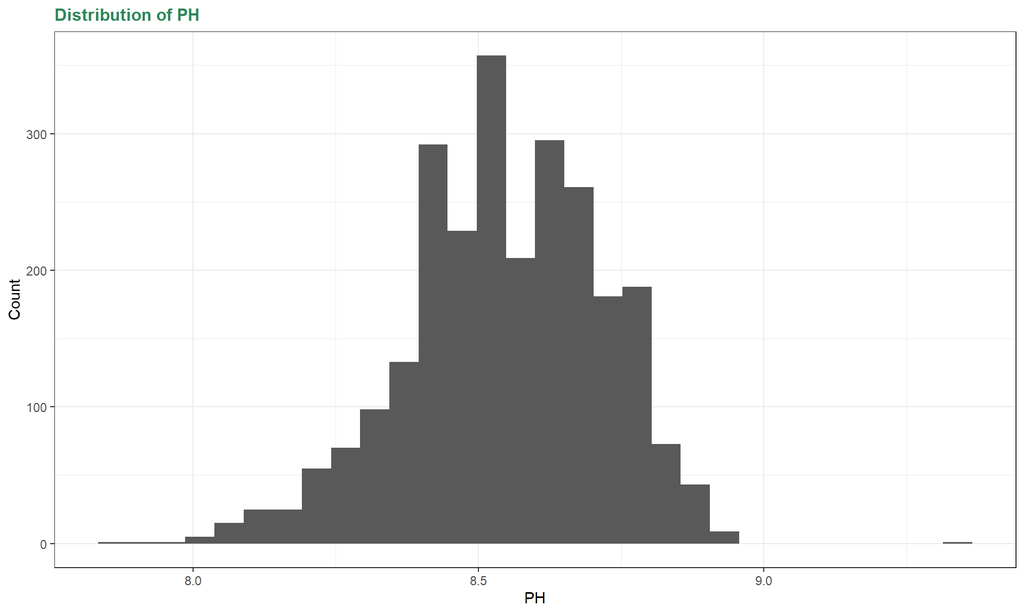

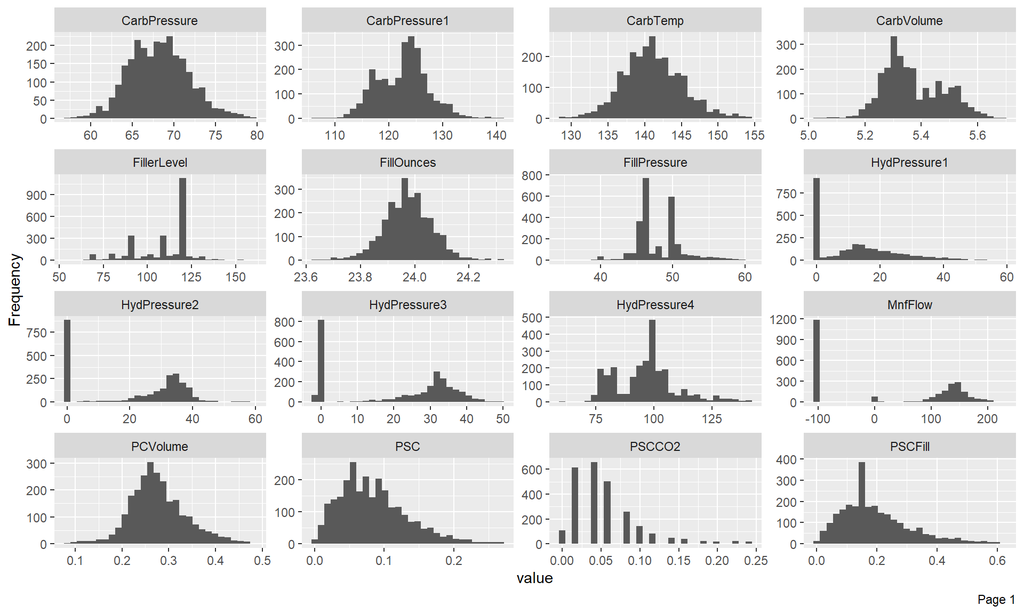

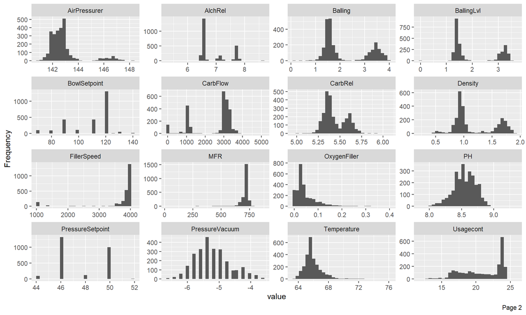

We observe evidence of outliers in addition to skew such as in the varibales Temperature. Based on the information we have gathered from our EDA, we can move into the data processing phase where we will address our findings. We will not know the true effect of outliers until we build and diagnose our models. We aniticipate linear model to perform worse than NNET.

## Data Preperation

We will use the MICE method to impute missing variables. We will also evaluate the which predictors have near zero variance. This will help us identify pedictors that need to be dropped from the data frame all together.We will hold off on removing predictors that have strong pairwise correlation until after we see how it affects our models. Andy has written code that nicely completes the data processing steps.

## Modeling

### Linear Models

Linear Model: The first model we will be building is the classical linear model. The linear model represents the taret variable as a function of its predictor variables. Beta represents the linear parameter estimate and epsilon represents the error term. $y={ \beta }_{ 0 }+\sum { { \beta }_{ i }{ X }_{ i }+{ \epsilon }_{ i } }$

There are some assumptions that need to be followed regarding linear regression. The first is that the residuals need to follow a near normal distribution and the second is that variance has to be constant. We have some diagnostic tests that can help us determine if these assumptions are satisfied or not. These assumptions need to be checked before we even consider taking into account how the model fits.

Linear Model 1 Variance Inflation Numbers

|  | GVIF | Df | GVIF^(1/(2*Df)) |
| --- | --- | --- | --- |
| BrandCode | 53.571866 | 3 | 1.941584 |
| CarbVolume | 13.634820 | 1 | 3.692536 |
| FillOunces | 1.160774 | 1 | 1.077392 |
| PCVolume | 1.502752 | 1 | 1.225868 |
| CarbPressure | 32.477299 | 1 | 5.698886 |
| CarbTemp | 26.671687 | 1 | 5.164464 |
| PSC | 1.153714 | 1 | 1.074111 |
| PSCFill | 1.100332 | 1 | 1.048967 |
| PSCCO2 | 1.071535 | 1 | 1.035150 |
| MnfFlow | 4.389162 | 1 | 2.095033 |
| CarbPressure1 | 1.572528 | 1 | 1.254005 |
| FillPressure | 2.074542 | 1 | 1.440327 |
| HydPressure2 | 9.197523 | 1 | 3.032742 |
| HydPressure3 | 12.507241 | 1 | 3.536558 |
| HydPressure4 | 2.650557 | 1 | 1.628053 |
| FillerLevel | 11.055076 | 1 | 3.324918 |
| FillerSpeed | 11.544613 | 1 | 3.397737 |
| Temperature | 1.400337 | 1 | 1.183358 |
| Usagecont | 1.703794 | 1 | 1.305295 |
| CarbFlow | 2.356651 | 1 | 1.535139 |
| Density | 16.299332 | 1 | 4.037243 |
| MFR | 9.832086 | 1 | 3.135616 |
| Balling | 71.779454 | 1 | 8.472276 |
| PressureVacuum | 2.685955 | 1 | 1.638888 |
| OxygenFiller | 1.522703 | 1 | 1.233979 |
| BowlSetpoint | 11.584124 | 1 | 3.403546 |
| PressureSetpoint | 2.268053 | 1 | 1.506006 |
| AirPressurer | 1.184406 | 1 | 1.088304 |
| AlchRel | 23.237818 | 1 | 4.820562 |
| CarbRel | 5.258863 | 1 | 2.293221 |
| BallingLvl | 54.441289 | 1 | 7.378434 |

```
     rstudent unadjusted p-value Bonferroni p
1093  5.85526         5.5454e-09   1.1396e-05
```

We fit a new LM with features showing high VIF removed.

Linear Model 2 Variable Importance

|  | Overall |
| --- | --- |
| BrandCodeB | 0.6751499 |
| BrandCodeC | 5.8589596 |
| BrandCodeD | 6.5503953 |
| CarbVolume | 2.2600273 |
| FillOunces | 2.1716942 |
| PCVolume | 1.5224876 |
| PSC | 1.5731511 |
| PSCFill | 1.2302135 |
| PSCCO2 | 2.7008473 |
| MnfFlow | 13.9429622 |
| CarbPressure1 | 7.5918084 |
| FillPressure | 2.0097608 |
| HydPressure2 | 1.4157779 |
| HydPressure3 | 4.6336202 |
| HydPressure4 | 0.7423533 |
| FillerLevel | 1.9066804 |
| FillerSpeed | 2.6517876 |
| Temperature | 6.2404708 |
| Usagecont | 5.7947060 |
| CarbFlow | 1.6203759 |
| Density | 3.5540669 |
| MFR | 3.5678464 |
| PressureVacuum | 0.1724955 |
| OxygenFiller | 3.8880210 |
| BowlSetpoint | 4.7217460 |
| PressureSetpoint | 4.3666264 |
| AirPressurer | 0.8192357 |
| CarbRel | 2.8073009 |

|  | PH |  |  | PH |  |  | PH |  |  |
| --- | --- | --- | --- | --- | --- | --- | --- | --- | --- |
| Predictors | Estimates | CI | p | Estimates | CI | p | Estimates | CI | p |
| (Intercept) | 11.36 | 9.01 – 13.71 | **<0.001** | 11.32 | 9.42 – 13.22 | **<0.001** | 11.75 | 9.76 – 13.74 | **<0.001** |
| BrandCode [B] | 0.07 | 0.02 – 0.12 | **0.005** | 0.01 | -0.02 – 0.05 | 0.500 |  |  |  |
| BrandCode [C] | -0.07 | -0.11 – -0.02 | **0.007** | -0.12 | -0.16 – -0.08 | **<0.001** |  |  |  |
| BrandCode [D] | 0.04 | 0.00 – 0.08 | **0.033** | 0.09 | 0.06 – 0.11 | **<0.001** |  |  |  |
| CarbVolume | -0.15 | -0.35 – 0.05 | 0.134 | -0.12 | -0.23 – -0.02 | **0.024** | 0.02 | -0.09 – 0.13 | 0.733 |
| FillOunces | -0.08 | -0.15 – -0.02 | **0.017** | -0.08 | -0.15 – -0.01 | **0.030** | -0.13 | -0.20 – -0.06 | **0.001** |
| PCVolume | -0.08 | -0.20 – 0.03 | 0.145 | -0.09 | -0.20 – 0.03 | 0.128 | -0.08 | -0.20 – 0.04 | 0.193 |
| CarbPressure | 0.00 | -0.00 – 0.01 | 0.364 |  |  |  |  |  |  |
| CarbTemp | -0.00 | -0.01 – 0.00 | 0.495 |  |  |  |  |  |  |
| PSC | -0.11 | -0.24 – 0.01 | 0.082 | -0.10 | -0.23 – 0.03 | 0.116 | -0.13 | -0.26 – 0.01 | 0.065 |
| PSCFill | -0.03 | -0.08 – 0.02 | 0.213 | -0.03 | -0.08 – 0.02 | 0.219 | -0.06 | -0.11 – -0.00 | **0.035** |
| PSCCO2 | -0.17 | -0.31 – -0.03 | **0.015** | -0.19 | -0.33 – -0.05 | **0.007** |  |  |  |
| MnfFlow | -0.00 | -0.00 – -0.00 | **<0.001** | -0.00 | -0.00 – -0.00 | **<0.001** | -0.00 | -0.00 – -0.00 | **<0.001** |
| CarbPressure1 | 0.01 | 0.00 – 0.01 | **<0.001** | 0.01 | 0.00 – 0.01 | **<0.001** | 0.01 | 0.00 – 0.01 | **<0.001** |
| FillPressure | 0.00 | -0.00 – 0.00 | 0.091 | 0.00 | 0.00 – 0.01 | **0.045** | 0.00 | -0.00 – 0.01 | 0.068 |
| HydPressure2 | -0.00 | -0.00 – 0.00 | 0.163 | -0.00 | -0.00 – 0.00 | 0.157 | -0.00 | -0.00 – 0.00 | 0.076 |
| HydPressure3 | 0.00 | 0.00 – 0.00 | **<0.001** | 0.00 | 0.00 – 0.00 | **<0.001** | 0.00 | 0.00 – 0.00 | **<0.001** |
| HydPressure4 | 0.00 | -0.00 – 0.00 | 0.673 | 0.00 | -0.00 – 0.00 | 0.458 | -0.00 | -0.00 – 0.00 | 0.190 |
| FillerLevel | -0.00 | -0.00 – 0.00 | 0.058 | -0.00 | -0.00 – 0.00 | 0.057 | -0.00 | -0.00 – 0.00 | 0.265 |
| FillerSpeed | 0.00 | 0.00 – 0.00 | **0.003** | 0.00 | 0.00 – 0.00 | **0.008** |  |  |  |
| Temperature | -0.01 | -0.02 – -0.01 | **<0.001** | -0.02 | -0.02 – -0.01 | **<0.001** | -0.02 | -0.02 – -0.01 | **<0.001** |
| Usagecont | -0.01 | -0.01 – -0.00 | **<0.001** | -0.01 | -0.01 – -0.00 | **<0.001** | -0.01 | -0.01 – -0.01 | **<0.001** |
| CarbFlow | 0.00 | -0.00 – 0.00 | 0.169 | 0.00 | -0.00 – 0.00 | 0.105 | 0.00 | -0.00 – 0.00 | 0.333 |
| Density | -0.11 | -0.17 – -0.05 | **<0.001** | -0.08 | -0.13 – -0.04 | **<0.001** | -0.07 | -0.10 – -0.04 | **<0.001** |
| MFR | -0.00 | -0.00 – -0.00 | **0.001** | -0.00 | -0.00 – -0.00 | **<0.001** |  |  |  |
| Balling | -0.10 | -0.15 – -0.04 | **<0.001** |  |  |  |  |  |  |
| PressureVacuum | -0.02 | -0.04 – -0.00 | **0.017** | -0.00 | -0.02 – 0.01 | 0.863 |  |  |  |
| OxygenFiller | -0.33 | -0.49 – -0.18 | **<0.001** | -0.31 | -0.47 – -0.15 | **<0.001** | -0.33 | -0.50 – -0.17 | **<0.001** |
| BowlSetpoint | 0.00 | 0.00 – 0.00 | **<0.001** | 0.00 | 0.00 – 0.00 | **<0.001** | 0.00 | 0.00 – 0.00 | **0.001** |
| PressureSetpoint | -0.01 | -0.01 – -0.00 | **<0.001** | -0.01 | -0.01 – -0.01 | **<0.001** | -0.01 | -0.02 – -0.01 | **<0.001** |
| AirPressurer | -0.00 | -0.01 – 0.00 | 0.349 | -0.00 | -0.01 – 0.00 | 0.413 | -0.00 | -0.01 – 0.00 | 0.406 |
| AlchRel | 0.12 | 0.06 – 0.17 | **<0.001** |  |  |  |  |  |  |
| CarbRel | 0.03 | -0.08 – 0.13 | 0.611 | 0.14 | 0.04 – 0.24 | **0.005** | 0.22 | 0.12 – 0.32 | **<0.001** |
| BallingLvl | 0.11 | 0.06 – 0.16 | **<0.001** |  |  |  |  |  |  |
| Observations | 2055 |  |  | 2055 |  |  | 2055 |  |  |
| R<sup>2</sup> / R<sup>2</sup> adjusted | 0.423 / 0.414 |  |  | 0.411 / 0.403 |  |  | 0.341 / 0.335 |  |  |

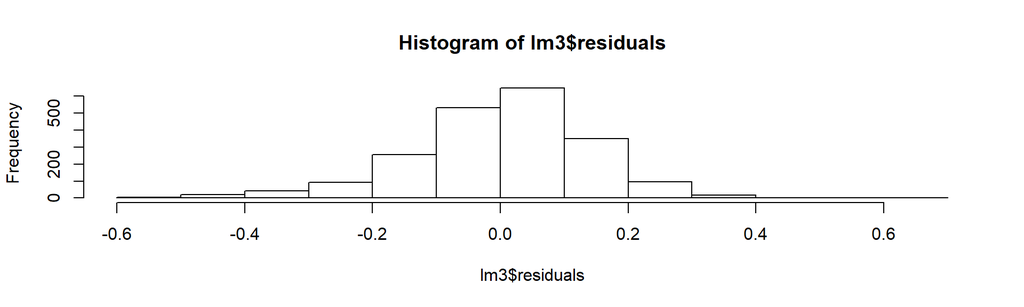

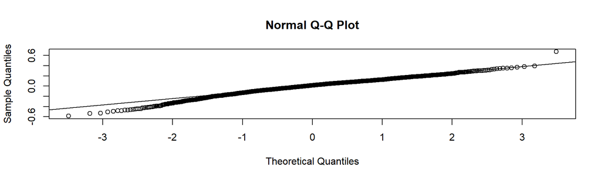

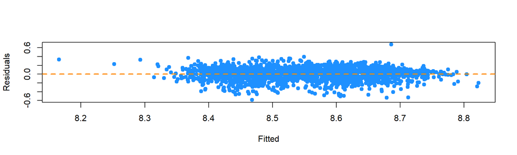

Our final LM seems to have near normal residuals and constant variance as can be seen in the provided visualizations. We will stick to this model to compare performance vs our NNEt model when we move into the prediciton phase.

### Model 2: NNET

```
Neural Network

2055 samples
  31 predictor

No pre-processing
Resampling: Bootstrapped (25 reps)
Summary of sample sizes: 2055, 2055, 2055, 2055, 2055, 2055, ...
Resampling results across tuning parameters:

  decay  size  RMSE      Rsquared     MAE
  0.1    4     7.548923  0.004735553  7.546913
  0.1    5     7.548920  0.004902776  7.546910
  0.1    6     7.548918  0.006375722  7.546908
  0.5    4     7.548970  0.008002717  7.546960
  0.5    5     7.548963  0.005447721  7.546953
  0.5    6     7.548954  0.006591334  7.546945

RMSE was used to select the optimal model using the smallest value.
The final values used for the model were size = 6 and decay = 0.1.
```